# Analysis of Prehistoric Iconography with the R package iconr

01 April 2021

# Background

By definition, prehistorical societies are characterized by the absence of a writing system. During, the largest part of human history, and everywhere in the world, symbolic expressions belong mostly to illiterate societies which express themselves with rock-art paintings, pottery decorations, figurines, statuary, etc., and a lot of now disappeared carved woods, textile design, etc. These graphical expressions are the most significant remaining part of humankind’s symbolism. At the composition level, the presence of recurrent patterns of signs (i.e., graphical syntax) in meaningful associations indicates the existence of social conventions in the way to display and to read these expressions. Well-established and shared methods to record and study these graphical contents would open the possibility of cross-cultural comparisons at a large scale and over the long-term.

# Statement of need

Ancient iconography is often perceived as different from other ‘*current*’ archaeological remains (lithics, potteries, settlements, etc., Chenorkian 1995). Indeed, the inherent variability of ancient iconography has led to considerable problems in its study, drastically limiting the possibility to draw a synthesis of graphic expressions at a large scale and over the long-term:

- Spatial proximities between the graphic units are not precisely quantified. Graphical units are attached to sub-areas of the support (e.g. upper part of a rock, neck of a pottery, centre of a stele).
- Groupings – like graphical units grouped into *figures*, *figures* grouped into *patterns*, *patterns* grouped into *motives*, etc. – are not self-explanatory and introduce a tedious number of groups and hinder their systematic analysis.
- Relationships and similarities between these groups are often not self-explanatory and unquantified.
- Descriptive vocabularies and methods of analysis are site-dependent or period-dependent.

Even the reevaluation of semiotics paradigms following the scientific trends – *structuralist turn* during the *Processual archaeology* period, ca 1960-1980 (De Saussure 1989; Binford 1962), *iconic turn* during the *Post-processual archaeology* period, ca 1980-2010 (Gell 1998; Hodder and others 1982), did not led to the development of efficient tools for ancient iconography studies, such as common descriptive variables, or common interpretation grids.

# Core functionality

The R package `iconr` is designed to offer a greater normalization of quantitative indexes for iconography studies (Alexander 2008; Huet 2018). It is grounded in graph theory and spatial analysis to offer concepts and functions for modeling prehistoric iconographic compositions and preparing them for further analysis: clustering, typology tree, Harris diagram (i.e. temporal succession of archaeological contexts, Harris 2014), etc. The main principle of the `iconr` package is to consider any iconographic composition (here, ‘decoration’) as a geometric graph of graphical units. Geometric graphs, also known as *planar graphs* or *spatialized graphs*, allow to model the neighborhood of these graphical unit which are the fundamental relationships of visual semiotics (Saint-Martin 2011). Graphical units are decorated surfaces (`POLYGONS`) modeled as nodes (`POINTS`) and tagged with semantic content (type, color, orientation, etc.). Separable graphical units showing a main graphical content (e.g., type = anthropomorphic figure) are considered as *main* nodes. Graphical units showing a specification of a *main* node (e.g. a sword handed by this anthropomorphic figure) are considered as *attribute* nodes. Each pair of *main* nodes thought to be contemporary that share a border (binary topological relationship: *touches*) of their Voronoi cells, are connected by an undirected edge (`LINES`).

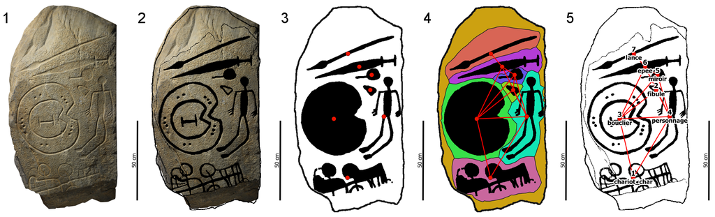

GIS view. The Late Bronze Age stele from Solana de Cabañas (Extremadura, Spain). 1. Original photograph (credits: Museo Arqueológico Nacional, Madrid); 2. Archaeological drawing of engraved parts (credits: Díaz-Guardamino Uribe 2010); 3. Digitalization/Polygonization of engraved parts (i.e., graphical units) and calculation of their their centroids (red points); 4. Voronoi diagram of each graphical unit (*seed*) and dual graph of the Voronoi diagram (i.e., Delaunay triangulation); 5. Identification of graphical units’ types

# Overview

The `iconr` package takes in charge of the geometric graphs management (step 5 in the previous figure). Steps 1 to 4 do not need to be included in the package since efficient implementations already exist: graph elements can be drawn directly on the decorated support drawing or photograph, preferably inside a GIS to make easier the calculation of nodes and edges coordinates. The `iconr` package allows the user to i) read data structures of nodes and edges (.tsv, .csv, .shp) and images (.jpg, .png, .tif, .gif, etc.), ii) plot nodes and edges separately, or together (geometric graph), over the decoration picture, iii) compare different decorations depending on common nodes or common edges. The package stable version is on the CRAN (Huet and Pozo 2021); the latest development version is available from GitHub (https://github.com/zoometh/iconr); the package documentation is available at https://zoometh.github.io/iconr/.

# Examples

## Read

Read the nodes of the Cerro Muriano 1 stele (Andalusia, Spain) with the function [`read_nds()`](https://zoometh.github.io/iconr/reference/read_nds.html).

```r
library(iconr)
dataDir <- system.file("extdata", package = "iconr")
site <- "Cerro Muriano"
decor <- "Cerro Muriano 1"
read_nds(site, decor, dataDir)
```

```
##            site           decor id          type        x         y
## 1 Cerro Muriano Cerro Muriano 1  1    personnage 349.8148 -298.3244
## 2 Cerro Muriano Cerro Muriano 1  2        casque 349.8148 -243.9851
## 3 Cerro Muriano Cerro Muriano 1  3         lance 238.4637 -298.3244
## 4 Cerro Muriano Cerro Muriano 1  4      bouclier 446.0222 -381.1697
## 5 Cerro Muriano Cerro Muriano 1  5        peigne 283.0041 -358.0086
## 6 Cerro Muriano Cerro Muriano 1  7 sexe_masculin 342.6884 -427.4917
## 7 Cerro Muriano Cerro Muriano 1  8    lingot_pdb 451.1489 -237.4782
```

## Plot

Plot the Cerro Muriano 1 stele decoration graph with the function [`plot_dec_grph()`](https://zoometh.github.io/iconr/reference/plot_dec_grph.html).

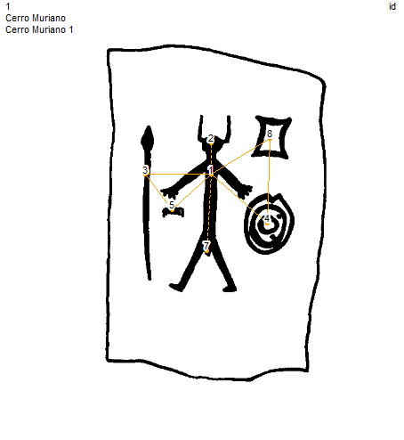

R view. Cerro Muriano 1 decoration graph. Between two *main* nodes, *normal* edges are shown as plain lines. Between *main* nodes and *attribute* nodes, *attribute* edges are shown as dotted lines drawing (credits: Díaz-Guardamino Uribe 2010)

```r
nds.df <- read_nds(site, decor, dataDir)
eds.df <- read_eds(site, decor, dataDir)
imgs <- read.table(paste0(dataDir, "/imgs.tsv"),
                   sep="\t", stringsAsFactors = FALSE)
plot_dec_grph(nds.df, eds.df, imgs,
              site, decor, dataDir)
```

## Compare

Compare and classify the `iconr` decoration training dataset according to pairwise comparisons between decorations based on their common nodes and common edges; functions [`list_dec()`](https://zoometh.github.io/iconr/reference/list_dec.html) and [`same_elements()`](https://zoometh.github.io/iconr/reference/same_elements.html).

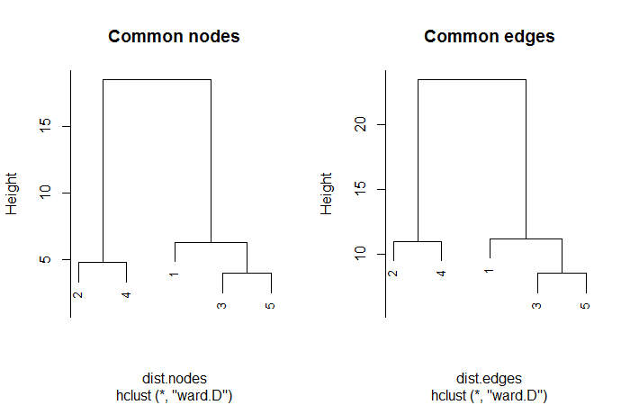

Results of the hierarchical clustering on the `iconr` decoration training dataset (five Late Bronze Age stelae) on common nodes (left) and common edges (right)

```r
imgs <- read.table(file.path(dataDir, "imgs.csv"), sep=";")
nodes <- read.table(file.path(dataDir, "nodes.csv"), sep=";")
edges <- read.table(file.path(dataDir, "edges.csv"), sep=";")
lgrph <- list_dec(imgs, nodes, edges)
df.same_edges <- same_elements(lgrph, "type", "edges")
df.same_nodes<- same_elements(lgrph, "type", "nodes")
dist.nodes <- dist(df.same_nodes, method = "euclidean")
dist.edges <- dist(df.same_edges, method = "euclidean")
hc.nds <- hclust(dist.nodes, method = "ward.D")
hc.eds <- hclust(dist.edges, method = "ward.D")
par(mfrow=c(1, 2))
plot(hc.nds, main = "Common nodes", cex = .8)
plot(hc.eds, main = "Common edges", cex = .8)
```

# Acknowledgements

This project was partly supported by the LabEx ARCHIMEDE from “Investissement d’Avenir” program ANR-11-LABX-0032-01.

# References

Alexander, Craig. 2008. “The Bedolina Map – an Exploratory Network Analysis.” In *Layers of Perception. Proceedings of the 35th International Conference on Computer Applications and Quantitative Methods in Archaeology (CAA), Berlin, 2.-6. April 2007*, edited by A. Posluschny, K. Lambers, and I. Herzog, 366–71. Koll. Vor- u. Frühgesch. https://doi.org/10.11588/propylaeumdok.00000512.

Binford, Lewis R. 1962. “Archaeology as Anthropology.” *American Antiquity*, 217–25.

Chenorkian, Robert. 1995. “Le Vestige Archéologique Gravure Rupestre: étude Et Interprétation.” In *L’homme méditerranéen (mélanges Offerts à Gabriel Camps)*, 157–78.

De Saussure, Ferdinand. 1989. *Cours de Linguistique générale*. Vol. 1. Otto Harrassowitz Verlag.

Díaz-Guardamino Uribe, Marta. 2010. “Las Estelas Decoradas En La Prehistoria de La Penı́nsula Ibérica.” PhD thesis, Universidad Complutense de Madrid, Servicio de Publicaciones. https://eprints.ucm.es/11070/1/T32200.pdf.

Gell, Alfred. 1998. *Art and Agency: An Anthropological Theory*. Clarendon Press.

Harris, Edward C. 2014. *Principles of Archaeological Stratigraphy*. Elsevier.

Hodder, Ian, and others. 1982. *Symbolic and Structural Archaeology*. Cambridge University Press Cambridge. https://doi.org/10.1017/CBO9780511558252.

Huet, Thomas. 2018. “Geometric Graphs to Study Ceramic Decoration.” In *Exploring Oceans of Data, Proceedings of the 44th Conference on Computer Applications and Quantitative Methods in Archaeology, CAA 2016*, edited by Mieko Matsumoto and Espen Uleberg, 311–24. Archaeopress. https://hal.archives-ouvertes.fr/hal-02913656.

Huet, Thomas, and Jose Pozo. 2021. *Iconr: Graphical and Spatial Analysis for Prehistoric Iconography*. https://CRAN.R-project.org/package=iconr.

Saint-Martin, Fernande. 2011. *Sémiologie Du Langage Visuel*. Presses de l’Université du Québec.